# Analiza oraz modelowanie wystąpienia cukrzycy

na podstawie zbioru danych dot. kobiet Indiańskiego plemienia

Autor

Weronika Nadworska

```r
library(tidyverse)
library(kableExtra)
library(corrplot)
library(caret)
library(rstatix)
library(tidymodels)
```

## Wstęp

Analizowany zbiór danych pochodzi z *National Institute of Diabetes and Digestive and Kidney Diseases*. Oparty jest na badaniach kobiet w wieku co najmniej 21 lat pochodzących z Indii, z plemienia Pima.

## Cel badania

Celem tego badania jest zidentyfikowanie cech pacjentek, które mogą mieć wpływ na wystapienie u nich cukrzycy oraz zbudowanie skutecznego modelu przewidywującego, czy pacjentka ma cukrzycę, w oparciu o określone pomiary diagnostyczne zawarte w zbiorze danych.

## Opis zbioru badawczego

Tabela poniżej przedstawia 6 początkowych wierszy zbioru badawczego.

```r
dane <- read.csv("Healthcare-Diabetes.csv")
head(dane) |> kable(caption = "Początkowe wiersze zbioru badawczego") |> kable_styling(full_width=T, bootstrap_options  = "striped")
```

Początkowe wiersze zbioru badawczego

| Id | Pregnancies | Glucose | BloodPressure | SkinThickness | Insulin | BMI | DiabetesPedigreeFunction | Age | Outcome |
| --- | --- | --- | --- | --- | --- | --- | --- | --- | --- |
| 1 | 6 | 148 | 72 | 35 | 0 | 33.6 | 0.627 | 50 | 1 |
| 2 | 1 | 85 | 66 | 29 | 0 | 26.6 | 0.351 | 31 | 0 |
| 3 | 8 | 183 | 64 | 0 | 0 | 23.3 | 0.672 | 32 | 1 |
| 4 | 1 | 89 | 66 | 23 | 94 | 28.1 | 0.167 | 21 | 0 |
| 5 | 0 | 137 | 40 | 35 | 168 | 43.1 | 2.288 | 33 | 1 |
| 6 | 5 | 116 | 74 | 0 | 0 | 25.6 | 0.201 | 30 | 0 |

```r
dane <- dane[,-1]
dane$Outcome <- as.factor(dane$Outcome)
```

Na zbiór danych składa się 2768 wierszy oraz 9 kolumn.

Zmiennymi w tym zbiorze danych są:

- `Id` - indeks oznaczający nr wiersza w zbiorze,
- `Pregnancies` - liczba ciąż, które ma za sobą pacjentka,
- `Glucose` - stężenie glukozy w osoczu w ciągu 2 godzin w doustnym teście tolerancji glukozy,
- `BloodPressure` - rozkurczowe ciśnienie krwi (mm Hg),
- `SkinThickness` - grubość fałdu skórnego tricepsa (mm),
- `Insulin` - 2-godzinna insulina w surowicy (mU/ml),
- `BMI` - wskaźnik BMI pacjentki,
- `DiabetesPedigreeFunction` - funkcja rodowodu cukrzycy, wynik genetyczny cukrzycy,
- `Age` - wiek pacjentki,
- `Outcome` - określa, czy pacjentka choruje na cukrzycę (1), czy nie (0).

Zmienna `Id` oznacza identyfikator pacjentki i nie będzie brana pod uwagę w dalszych analizach.

Dane nie zawierają braków.

W tabeli poniżej przedstawiono podstawowe statystyki opisowe dla zmiennych numerycznych w tym zbiorze danych.

```r
options(knitr.kable.NA=0)
pods <- sub(".*:", "", summary(dane[,-ncol(dane)]))
rownames(pods) <- c("Min.", "Q1", "Median", "Mean", "Q3", "Max.")
pods |> kable(caption = "Statystyki opisowe zmiennych numerycznych") |> kable_styling(full_width = T, bootstrap_options  = "striped") |> column_spec(column = 1, bold = T)
```

Statystyki opisowe zmiennych numerycznych

|  | Pregnancies | Glucose | BloodPressure | SkinThickness | Insulin | BMI | DiabetesPedigreeFunction | Age |
| --- | --- | --- | --- | --- | --- | --- | --- | --- |
| Min. | 0.000 | 0.0 | 0.00 | 0.00 | 0.00 | 0.00 | 0.0780 | 21.00 |
| Q1 | 1.000 | 99.0 | 62.00 | 0.00 | 0.00 | 27.30 | 0.2440 | 24.00 |
| Median | 3.000 | 117.0 | 72.00 | 23.00 | 37.00 | 32.20 | 0.3750 | 29.00 |
| Mean | 3.743 | 121.1 | 69.13 | 20.82 | 80.13 | 32.14 | 0.4712 | 33.13 |
| Q3 | 6.000 | 141.0 | 80.00 | 32.00 | 130.00 | 36.62 | 0.6240 | 40.00 |
| Max. | 17.000 | 199.0 | 122.00 | 110.00 | 846.00 | 80.60 | 2.4200 | 81.00 |

Na jej podstawie można wyciągnąć wnioski, że:

- badane pacjentki były w wieku 21-81 lat, ale zwykle miały ok. 25-29 lat,
- najmniejsze wartości dla zmiennych `Glucose`, `BloodPressure`, `SkinThickness`, `Insulin` oraz `BMI` równe zero są zastanawiające, ponieważ u zdrowego, żyjącego człowieka nie mogą występować takie wartości,
- ciekawostką jest to, że w badaniu wzięła udział pacjentka, która miała 17 dzieci. Zwykle jednak badane kobiety miały ich trójkę.
- Zastanawiający jest maksymalny poziom insuliny w surowicy równy ponad 800. Zwykle po dwóch godzinach wartość ta nie powinna przekraczać 30 mU/ml. Tutaj nawet mediana przewyższa tę wartość.

```r
dane[dane$Glucose==0 | dane$BloodPressure==0 | dane$SkinThickness==0 | dane$Insulin==0 | dane$BMI==0,] |> nrow() #1341
```

```
[1] 1341
```

```r
dane[dane$Insulin>100,] |> nrow() #891
```

```
[1] 891
```

Po zidentyfikowaniu danych o pacjentkach, dla których wartość co najmniej jednej ze zmiennych `Glucose`, `BloodPressure`, `SkinThickness`, `Insulin` oraz `BMI` wynosi 0, okazało się, że takich przypadków jest 1341. To stanowi połowę wszystkich przebadanych pacjentek.

Liczba pacjentek, dla których zmienna `Insulin` przekracza 100 wynosi 891 - to około $\frac{1}{3}$ całego zbioru danych.

Skoro potencjalnych błędów w tym zbiorze danych jest aż tyle, prowokuje to do zadania pytania, czy może wartości 0 nie zostały w tym zbiorze zakodowane jako braki danych.

Kwestia zmiennej `Insulin` nadal pozostaje zastanawiająca. Jej wartości wahają się między zero (1330 przypadków) a 846 (wartość znacznie przekraczającą normę dla tego parametru). Być może kobiety z tego plemienia charakteryzują się nieco innymi cechami medycznymi(?), jednak nadal pozostaje ona kwestią otwartą. Być może kolejne etapy EDA pozwolą na pewne decyzje w tej sprawie.

```r
dane[dane$Insulin==0,] |> nrow() #1330
```

```
[1] 1330
```

```r
max(dane$Insulin) #846
```

```
[1] 846
```

```r
findLinearCombos(dane) #brak
```

```
$linearCombos
list()

$remove
NULL
```

```r
nzv(dane) #Insulin
```

```
[1] 5
```

##### Macierz korelacji

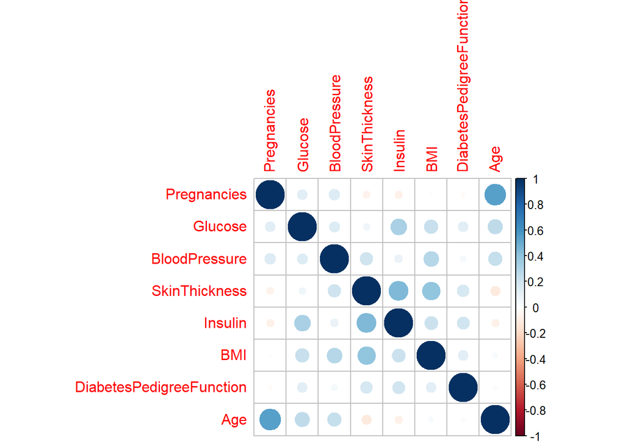

```r
dane |>
  dplyr::select(where(is.numeric)) |>
  cor() |>
  corrplot::corrplot()
```

```r
cor(dane$Age, dane$Pregnancies)
```

```
[1] 0.5408052
```

Na podstawie widocznej wyżej macierzy korelacji pomiędzy zmiennymi można dostrzec, że nie występują silne korelacje w tym zbiorze danych. Najwyższa wartość współczynnika korelacji pomiędzy zmiennymi numerycznymi w tym zbiorze wynosi 0,54 i jest to korelacja pomiędzy zmiennymi `Age` (wiek pacjentki) oraz `Pregnancies` (liczba ciąż).

Dla zmiennej kategorycznej `Outcome` zaprezentowano jej możliwe poziomy oraz liczby wystąpień każdego poziomu.

```r
options(knitr.kable.NA='')
summary(dane["Outcome"]) %>% kable() %>% kable_styling(full_width = F, bootstrap_options  = "striped")
```

|  | Outcome |
| --- | --- |
|  | 0:1816 |
|  | 1: 952 |

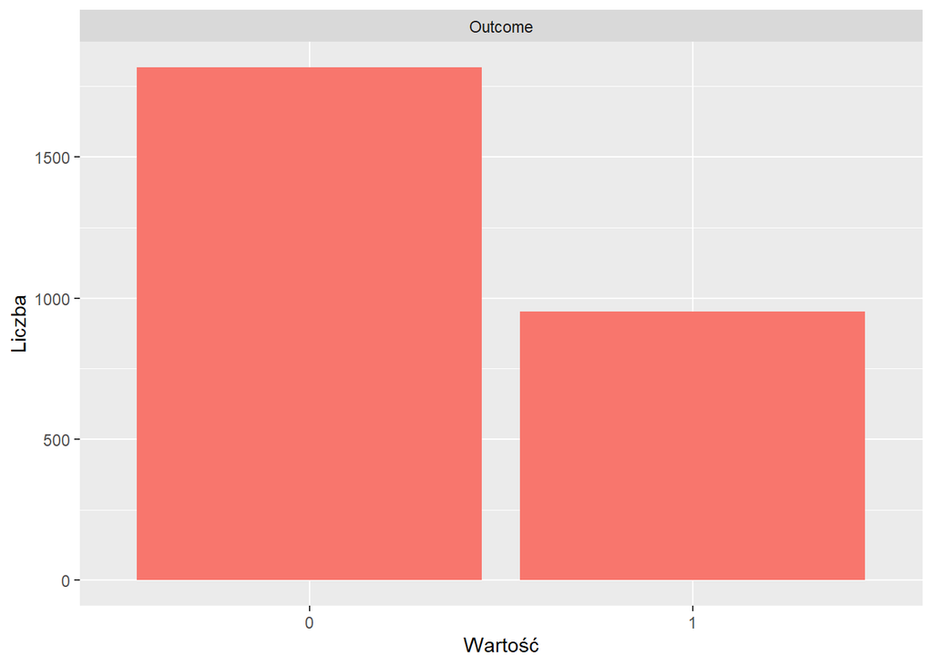

```r
dane |> select("Outcome") |>
  pivot_longer(cols = everything()) |>
  ggplot(aes(value, fill = name)) +
  geom_bar()+
  facet_wrap(~name, scales = "free")+
  theme(legend.position = "none")+
  xlab("Wartość")+
  ylab("Liczba")
```

##### Rozkłady zmiennych

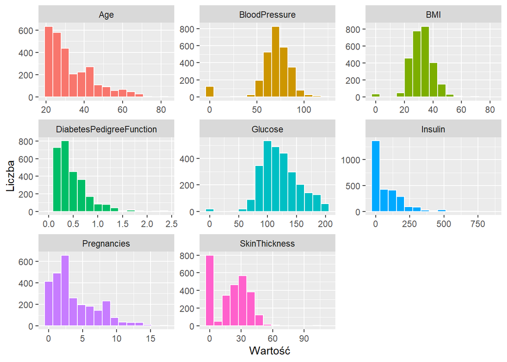

```r
dane |> select(-"Outcome") |>
  pivot_longer(cols = everything()) |>
  ggplot(aes(value, fill = name)) +
  geom_histogram(bins = 15, color = "white")+
  facet_wrap(~name, scales = "free")+
  theme(legend.position = "none")+
  xlab("Wartość")+
  ylab("Liczba")
```

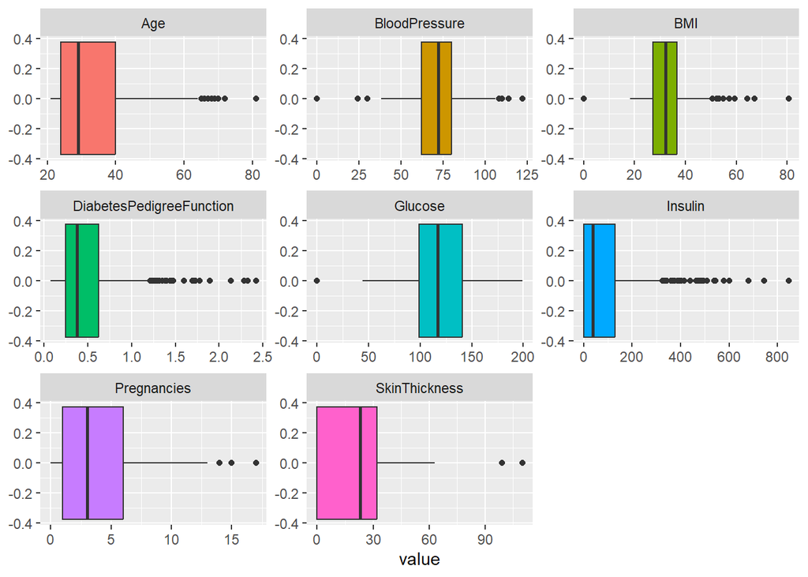

```r
dane |>
  select(-"Outcome") |>
  pivot_longer(cols = everything()) |>
  ggplot(aes(value, fill = name)) +
  geom_boxplot()+
  facet_wrap(~name, scales = "free")+
  theme(legend.position = "none")
```

Wykresy ramka-wąsy dla zmiennych numerycznych w tym zbiorze również potwierdzają zaobserwowane wyżej wnioski o asymetriach rozkładów większości zmiennych. Dodatkowo, widoczne są także wartości odstające dla każdej ze zmiennych.

**Podsumowanie EDA**

Zera w tym zbiorze danych zostaną zakodowane jako braki danych (tylko dla zmiennych `BloodPressure`, `BMI`, `Glucose`, `Insulin` oraz `SkinThickness`). Następnie nastąpi ich imputacja. Być może to przyniesie korektę rozkładów zmiennych oraz pozwoli na wyciągnięcie prawidłowych wniosków z badania.

```r
dane[dane$BloodPressure==0,3] <- NA
dane[dane$BMI==0,6] <- NA
dane[dane$Glucose==0,2] <- NA
dane[dane$Insulin==0,5] <- NA
dane[dane$SkinThickness==0,4] <- NA
```

W tym momencie braki danych rozkładają się następująco na poszczególne kolumny w zbiorze:

```r
braki <- colSums(is.na(dane))
braki <- cbind(braki)
colnames(braki) <- "Liczba braków"
braki |> kable() |> kable_styling(full_width = F, bootstrap_options  = "striped")
```

|  | Liczba braków |
| --- | --- |
| Pregnancies | 0 |
| Glucose | 18 |
| BloodPressure | 125 |
| SkinThickness | 800 |
| Insulin | 1330 |
| BMI | 39 |
| DiabetesPedigreeFunction | 0 |
| Age | 0 |
| Outcome | 0 |

##### Wartości odstające

Teraz w zbiorze jest 2681 wierszy.

Rozkłady zmiennych po usunięciu obserwacji odstających:

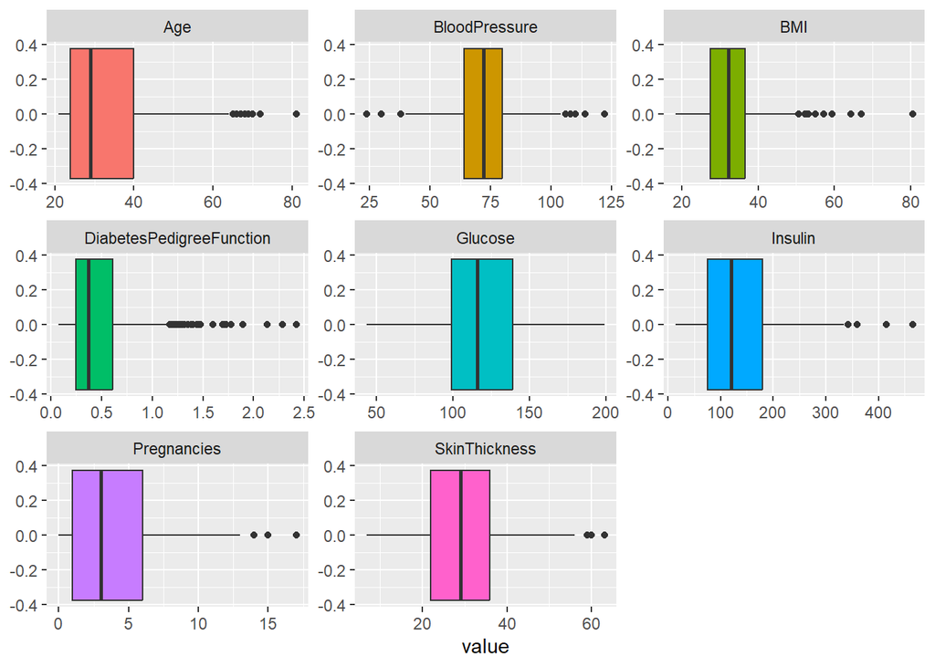

```r
dane |>
  select(-"Outcome") |>
  pivot_longer(cols = everything()) |>
  ggplot(aes(value, fill = name)) +
  geom_boxplot()+
  facet_wrap(~name, scales = "free")+
  theme(legend.position = "none")
```

##### Imputacja braków danych

Braki danych w zmiennej BloodPressure (123 przypadki) oraz Glucose (18) zostaną zastąpione średnią, ponieważ ich rozkład jest zbliżony do rozkładu normalnego. Dla zmiennej SkinThickness (800 przypadków), BMI (39 przypadków) oraz Insulin (1327) zastosowana zostanie metoda $k$-najbliższych sąsiadów w procesie imputacji braków danych.

```r
dane[is.na(dane$BloodPressure)==T,3] <- mean(dane$BloodPressure, na.rm = T) |> round(digits = 0)
dane[is.na(dane$Glucose)==T,2] <- mean(dane$Glucose, na.rm = T) |> round(digits = 0)
dane <- DMwR2::knnImputation(dane, k=5, scale=T, meth='pmm')
```

Rozkłady zmiennych po imputacji braków danych:

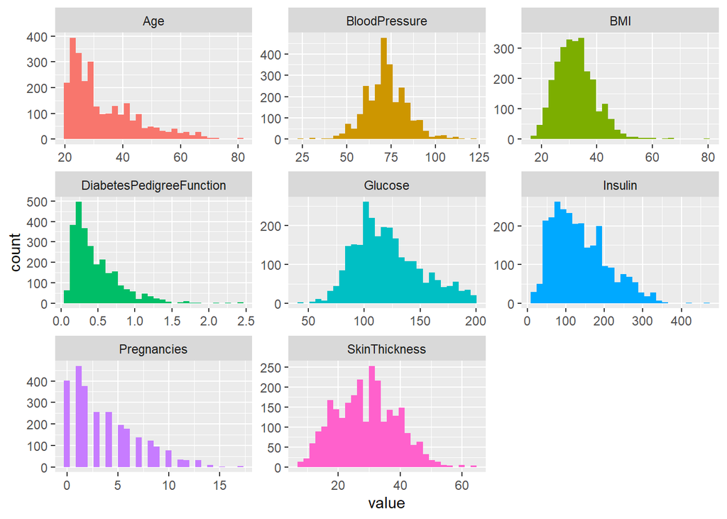

```r
dane |>
  select(-"Outcome") |>
  pivot_longer(cols = everything()) |>
  ggplot(aes(value, fill = name)) +
  geom_histogram()+
  facet_wrap(~name, scales = "free")+
  theme(legend.position = "none")
```

Można wyciągnąć wniosek, że rozkłady zmiennych poprawiły się ze względu na asymetrię - usunięcie obserwacji odstających wpłynęło na ich korektę.

## Analiza statystyczna występowania cukrzcy

```r
alfa <- 0.05
```

W badaniu przyjęto poziom istotności $\alpha=0,05$.

#### ze względu na wiek pacjentki

```r
# przedział ufności dla średniej, model 3 bo nie wiemy o normalnosci, a l. próbek>100
x <- mean(dane$Age)
u <- qnorm(1-alfa/2)
s <- sd(dane$Age)
n <- nrow(dane)
lk <- x-u*s/sqrt(n-1)
pk <- x+u*s/sqrt(n-1)
```

Przedział ufności dla średniego wieku ma postać (32.71, 33.6).

```r
lk <- s/(1+u/sqrt(2*n))
pk <- s/(1-u/sqrt(2*n))
```

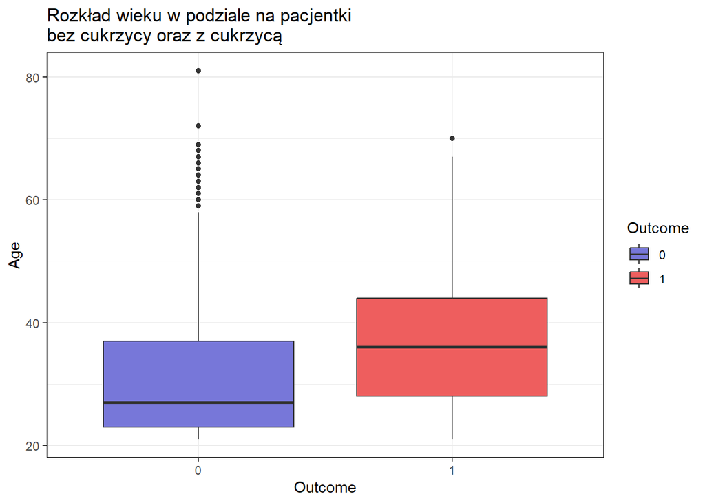

```r
ggplot(dane, aes(x=Outcome, y=Age, fill=Outcome))+
  geom_boxplot()+
  scale_fill_manual(values=c("#7777D9", "#ee5e5e"))+
  labs(title="Rozkład wieku w podziale na pacjentki \nbez cukrzycy oraz z cukrzycą")+
  theme_bw()
```

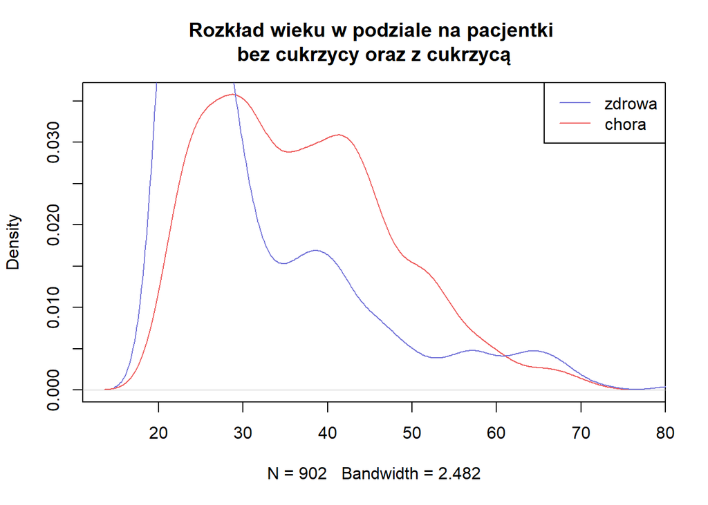

```r
plot(density(dane$Age[dane$Outcome==1]), col="#ee5e5e", main="Rozkład wieku w podziale na pacjentki \nbez cukrzycy oraz z cukrzycą")
lines(density(dane$Age[dane$Outcome==0]), col="#7777D9")
legend("topright", legend=c("zdrowa", "chora"), col=c("#7777D9", "#ee5e5e"), lty=1)
```

Zarówno z wykresu ramka-wąsy, jak i z wykresu gęstości, widać wyraźnie, że w grupie pacjentek chorych na cukrzycę częściej występują pacjentki z większym wiekiem, niż ma to miejsce w grupie pacjentek zdrowych. Z wykresu ramka-wąsy widać także, że dla grupy chorych typowe wartości wieku zaczynają się od około 30 lat i obejmują wiek do 45 lat, podczas gdy dla grupy zdrowych typowy wiek mieści się w przedziale od 23 do 37.

```r
dane %>%
  group_by(Outcome) |>
  summarise(Min=min(Age),
            Q1=quantile(Age, 0.25),
            Mean=mean(Age),
            Q3=quantile(Age, 0.75),
            Max=max(Age),
            sd=sd(Age),
            V=sd(Age)/mean(Age)*100,
            n=n()) |>
  kable() |>
  kable_styling(bootstrap_options = "striped")
```

| Outcome | Min | Q1 | Mean | Q3 | Max | sd | V | n |
| --- | --- | --- | --- | --- | --- | --- | --- | --- |
| 0 | 21 | 23 | 31.21754 | 37 | 81 | 11.78135 | 37.73953 | 1779 |
| 1 | 21 | 28 | 36.98004 | 44 | 70 | 10.75484 | 29.08283 | 902 |

Z tabeli ze statystykami opisowymi możemy zauważyć, że średnia wieku w grupie bez cukrzycy wynosi około 31, a w grupie z cukrzycą niemal 37, a więc jest nieco wyższa. W grupie z cukrzycą odchylenie standardowe dla wieku jest nieco niższe. Zróżnicowanie tej cechy jest więc nieco mniejsze niż w grupie bez cukrzycy, co oznacza, że wartości są trochę bardziej skupione blisko średniej. Tę różnicę widać tym bardziej we współczynnikach zmienności. Dla grupy zdrowych pacjentek współczynnik zmienności wieku wynosi około 38%, czyli zmienność jest poniżej średniej. Dla grupy pacjentek chorych na cukrzycę ta wartość wynosi 29%, a więc zmienność wieku jest nieco mniejsza w tej grupie.

Poniżej wyświetlono wyniki testu Shapiro-Wilka dla obu grup pacjentów dla zmiennej `Age`. W obu grupach p-value z testu jest bardzo bliskie zeru. Jednoznacznie należy odrzucić hipotezę o normalności rozkładu wieku w grupach.

```r
dane |>
  group_by(Outcome) |>
  shapiro_test(Age) |>
  kable() |>
  kable_styling()
```

| Outcome | variable | statistic | p |
| --- | --- | --- | --- |
| 0 | Age | 0.7965790 | 0 |
| 1 | Age | 0.9564472 | 0 |

Przeprowadzono również test równości wariancji wieku w grupach. Na podstawie wcześniej opisanych statystyk, można przypuszczać, że wariancje wieku w grupach nie są równe. Test $F$ potwierdza te przypuszczenia (p-value jest bardzo bliskie zeru).

```r
var.test(dane[dane$Outcome==0, 'Age'], dane[dane$Outcome==1, 'Age'])
```

```
    F test to compare two variances

data:  dane[dane$Outcome == 0, "Age"] and dane[dane$Outcome == 1, "Age"]
F = 1.2, num df = 1778, denom df = 901, p-value = 0.001853
alternative hypothesis: true ratio of variances is not equal to 1
95 percent confidence interval:
 1.070203 1.342676
sample estimates:
ratio of variances
          1.200002
```

Wariancje w obu grupach są różne i nie pojawia się rozkład normalny. Testem odpowiednim do sprawdzenia równości średniej wieku w grupach przy takich założeniach byłby test Manna-Whitneya. Z powodu dużej liczebności próby zdecydowano się użyć jednak testu $T$, mimo braku normalności.

```r
t.test(dane[dane$Outcome==0, 'Age'], dane[dane$Outcome==1, 'Age'], var.equal = F, alternative = "less")
```

```
    Welch Two Sample t-test

data:  dane[dane$Outcome == 0, "Age"] and dane[dane$Outcome == 1, "Age"]
t = -12.688, df = 1962.7, p-value < 2.2e-16
alternative hypothesis: true difference in means is less than 0
95 percent confidence interval:
      -Inf -5.015138
sample estimates:
mean of x mean of y
 31.21754  36.98004
```

Wiek może być zatem czynnikiem wpływającym na wystąpienie cukrzycy u badanych pacjentek.

### ze względu na poziom glukozy we krwi

```r
x <- mean(dane$Glucose)
u <- qnorm(1-alfa/2)
s <- sd(dane$Glucose)
n <- nrow(dane)
lk <- x-u*s/sqrt(n-1)
pk <- x+u*s/sqrt(n-1)
```

```r
lk <- s/(1+u/sqrt(2*n))
pk <- s/(1-u/sqrt(2*n))
```

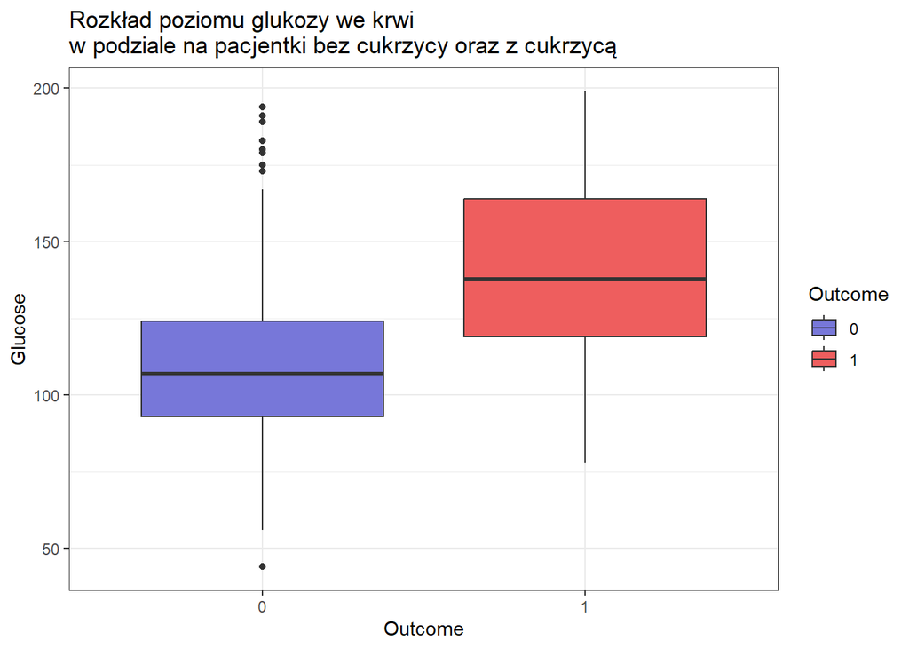

```r
ggplot(dane, aes(x=Outcome, y=Glucose, fill=Outcome))+
  geom_boxplot()+
  scale_fill_manual(values=c("#7777D9", "#ee5e5e"))+
  labs(title="Rozkład poziomu glukozy we krwi \nw podziale na pacjentki bez cukrzycy oraz z cukrzycą")+
  theme_bw()
```

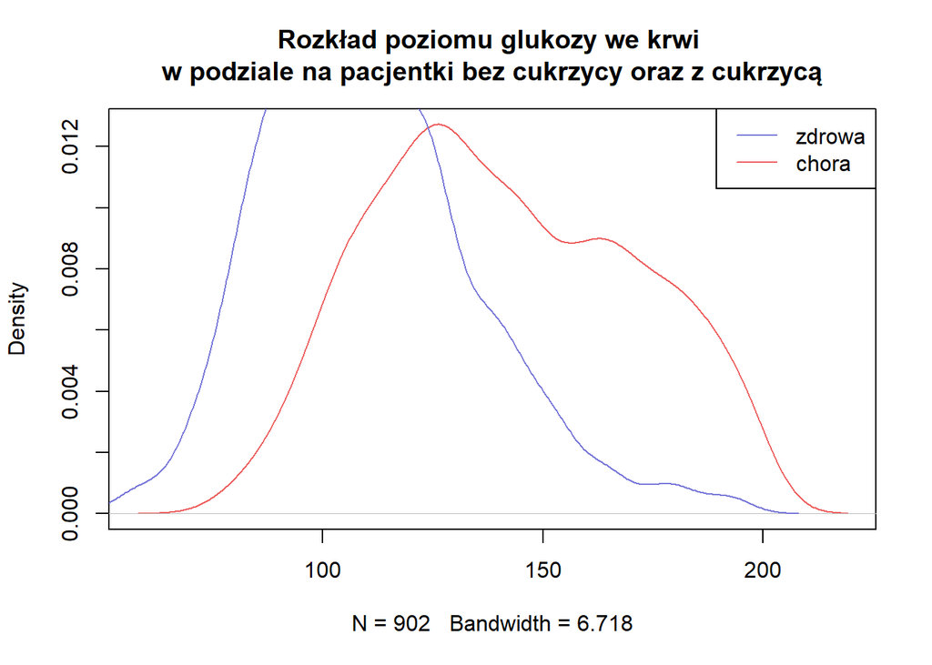

```r
plot(density(dane$Glucose[dane$Outcome==1]), col="#ee5e5e", main="Rozkład poziomu glukozy we krwi \nw podziale na pacjentki bez cukrzycy oraz z cukrzycą")
lines(density(dane$Glucose[dane$Outcome==0]), col="#7777D9")
legend("topright", legend=c("zdrowa", "chora"), col=c("#7777D9", "#ee5e5e"), lty=1)
```

```r
dane |>
  group_by(Outcome) |>
  summarise(Min=min(Glucose),
            Q1=quantile(Glucose, 0.25),
            Mean=mean(Glucose),
            Q3=quantile(Glucose, 0.75),
            Max=max(Glucose),
            sd=sd(Glucose),
            V=sd(Glucose)/mean(Glucose)*100,
            n=n()) |>
  kable() |>
  kable_styling(bootstrap_options = "striped")
```

| Outcome | Min | Q1 | Mean | Q3 | Max | sd | V | n |
| --- | --- | --- | --- | --- | --- | --- | --- | --- |
| 0 | 44 | 93 | 110.1439 | 124 | 194 | 24.29271 | 22.05543 | 1779 |
| 1 | 78 | 119 | 141.1408 | 164 | 199 | 29.10773 | 20.62319 | 902 |

Z tabeli ze statystykami opisowymi możemy zauważyć, że średnia poziomu glikozy we krwi w grupie bez cukrzycy wynosi około 110, a w grupie z cukrzycą ponad 140, a więc jest wyższa. W grupie z cukrzycą odchylenie standardowe dla analizowanego czynnika wyższe. Zróżnicowanie tej cechy jest więc większe niż w grupie bez cukrzycy, co oznacza, że wartości są mniej skupione blisko średniej. Zmienność w grupie zdrowych wynosi tu 22%, a w grupie chorych niecałe 21%, nie ma tu zatem dużych różnic.

Poniżej wyświetlono wyniki testu Shapiro-Wilka dla obu grup pacjentów dla zmiennej `Glucose`. W obu grupach p-value z testu jest bardzo bliskie zeru. Jednoznacznie należy odrzucić hipotezę o normalności rozkładu poziomu glukozy we krwi w grupach.

```r
dane |>
  group_by(Outcome) |>
  shapiro_test(Glucose) |>
  kable() |>
  kable_styling()
```

| Outcome | variable | statistic | p |
| --- | --- | --- | --- |
| 0 | Glucose | 0.9749827 | 0 |
| 1 | Glucose | 0.9749902 | 0 |

Przeprowadzono również test równości wariancji tej zmiennej w grupach. Na podstawie wcześniej opisanych statystyk, można przypuszczać, że wariancje poziomu glukozy we krwi w grupach nie są równe. Test $F$ potwierdza te przypuszczenia (p-value jest bardzo bliskie zeru).

```r
var.test(dane[dane$Outcome==0, 'Glucose'], dane[dane$Outcome==1, 'Glucose'])
```

```
    F test to compare two variances

data:  dane[dane$Outcome == 0, "Glucose"] and dane[dane$Outcome == 1, "Glucose"]
F = 0.69652, num df = 1778, denom df = 901, p-value = 1.914e-10
alternative hypothesis: true ratio of variances is not equal to 1
95 percent confidence interval:
 0.6211827 0.7793354
sample estimates:
ratio of variances
         0.6965226
```

```r
t.test(dane[dane$Outcome==0, 'Glucose'], dane[dane$Outcome==1, 'Glucose'], var.equal = F, alternative = "less")
```

```
    Welch Two Sample t-test

data:  dane[dane$Outcome == 0, "Glucose"] and dane[dane$Outcome == 1, "Glucose"]
t = -27.494, df = 1551.7, p-value < 2.2e-16
alternative hypothesis: true difference in means is less than 0
95 percent confidence interval:
      -Inf -29.14138
sample estimates:
mean of x mean of y
 110.1439  141.1408
```

Test $T$ każe nam odrzucić hipotezę o równości średniego poziomu glkozy we krwi w grupach pacjentek chorych na cukrzycę oraz zdrowych (p-value bliskie zeru).

Poziom glukozy we krwi może być zatem czynnikiem wpływającym na wystąpienie cukrzycy.

### ze względu na poziom ciśnienia tętniczego

```r
x <- mean(dane$BloodPressure)
u <- qnorm(1-alfa/2)
s <- sd(dane$BloodPressure)
n <- nrow(dane)
lk <- x-u*s/sqrt(n-1)
pk <- x+u*s/sqrt(n-1)
```

```r
lk <- s/(1+u/sqrt(2*n))
pk <- s/(1-u/sqrt(2*n))
```

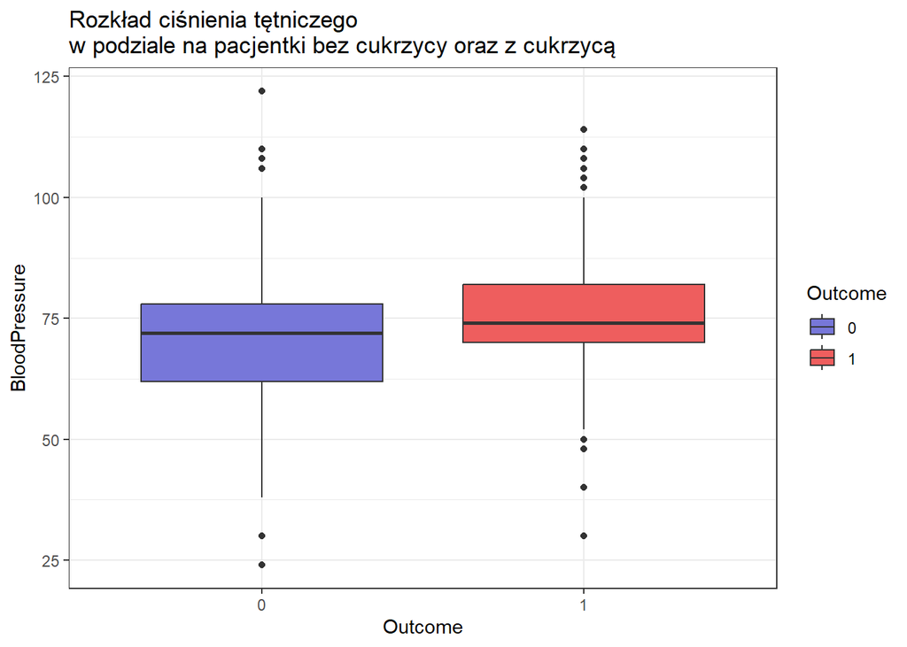

```r
ggplot(dane, aes(x=Outcome, y=BloodPressure, fill=Outcome))+
  geom_boxplot()+
  scale_fill_manual(values=c("#7777D9", "#ee5e5e"))+
  labs(title="Rozkład ciśnienia tętniczego \nw podziale na pacjentki bez cukrzycy oraz z cukrzycą")+
  theme_bw()
```

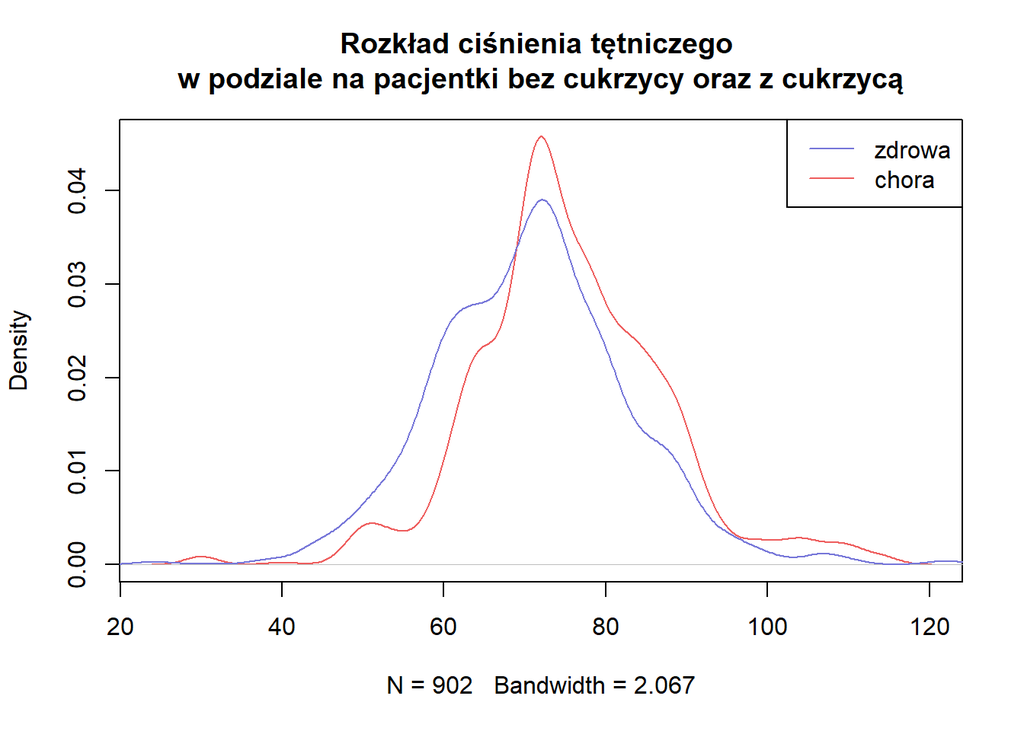

```r
plot(density(dane$BloodPressure[dane$Outcome==1]), col="#ee5e5e", main="Rozkład ciśnienia tętniczego \nw podziale na pacjentki bez cukrzycy oraz z cukrzycą")
lines(density(dane$BloodPressure[dane$Outcome==0]), col="#7777D9")
legend("topright", legend=c("zdrowa", "chora"), col=c("#7777D9", "#ee5e5e"), lty=1)
```

Zarówno z wykresu ramka-wąsy, jak i z wykresu gęstości, nie widać wyraźnych różnic pomiędzy grupami pacjentek chorych na cukrzycę oraz zdrowych.

```r
dane |>
  group_by(Outcome) |>
  summarise(Min=min(BloodPressure),
            Q1=quantile(BloodPressure, 0.25),
            Mean=mean(BloodPressure),
            Q3=quantile(BloodPressure, 0.75),
            Max=max(BloodPressure),
            sd=sd(BloodPressure),
            V=sd(BloodPressure)/mean(BloodPressure)*100,
            n=n()) |>
  kable() |>
  kable_styling(bootstrap_options = "striped")
```

| Outcome | Min | Q1 | Mean | Q3 | Max | sd | V | n |
| --- | --- | --- | --- | --- | --- | --- | --- | --- |
| 0 | 24 | 62 | 70.89770 | 78 | 122 | 11.85347 | 16.71912 | 1779 |
| 1 | 30 | 70 | 75.44678 | 82 | 114 | 11.68040 | 15.48164 | 902 |

Z tabeli ze statystykami opisowymi możemy zauważyć, że średnia wartość ciśneinia tętniczego w grupie pacjentek bez cukrzycy wynosi około 71, a w grupie z cukrzycą ponad 75, a więc jest nieco wyższa, jednak nieznacznie. Odchylenie standardowe dla analizowanego czynnika jest na podobnym poziomie w obu grupach. Zróżnicowanie tej cechy nie jest więc znaczące. Zmienność w grupie zdrowych wynosi tu niemal 17%, a w grupie chorych niecałe 16%, jest ono zatem bardzo zbliżone.

```r
dane |>
  group_by(Outcome) |>
  shapiro_test(BloodPressure) |>
  kable() |>
  kable_styling()
```

| Outcome | variable | statistic | p |
| --- | --- | --- | --- |
| 0 | BloodPressure | 0.9873489 | 0 |
| 1 | BloodPressure | 0.9738796 | 0 |

```r
var.test(dane[dane$Outcome==0, 'BloodPressure'], dane[dane$Outcome==1, 'BloodPressure'])
```

```
    F test to compare two variances

data:  dane[dane$Outcome == 0, "BloodPressure"] and dane[dane$Outcome == 1, "BloodPressure"]
F = 1.0299, num df = 1778, denom df = 901, p-value = 0.6161
alternative hypothesis: true ratio of variances is not equal to 1
95 percent confidence interval:
 0.9184591 1.1522982
sample estimates:
ratio of variances
          1.029854
```

### ze względu na poziom insuliny we krwi

```r
x <- mean(dane$Insulin)
u <- qnorm(1-alfa/2)
s <- sd(dane$Insulin)
n <- nrow(dane)
lk <- x-u*s/sqrt(n-1)
pk <- x+u*s/sqrt(n-1)
```

```r
lk <- s/(1+u/sqrt(2*n))
pk <- s/(1-u/sqrt(2*n))
```

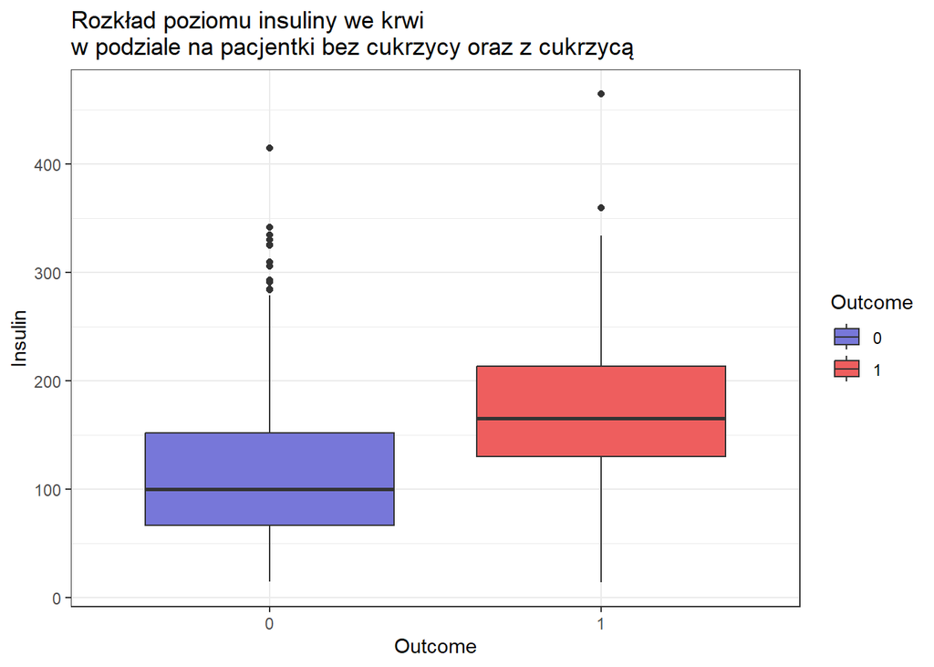

```r
ggplot(dane, aes(x=Outcome, y=Insulin, fill=Outcome))+
  geom_boxplot()+
  scale_fill_manual(values=c("#7777D9", "#ee5e5e"))+
  labs(title="Rozkład poziomu insuliny we krwi \nw podziale na pacjentki bez cukrzycy oraz z cukrzycą")+
  theme_bw()
```

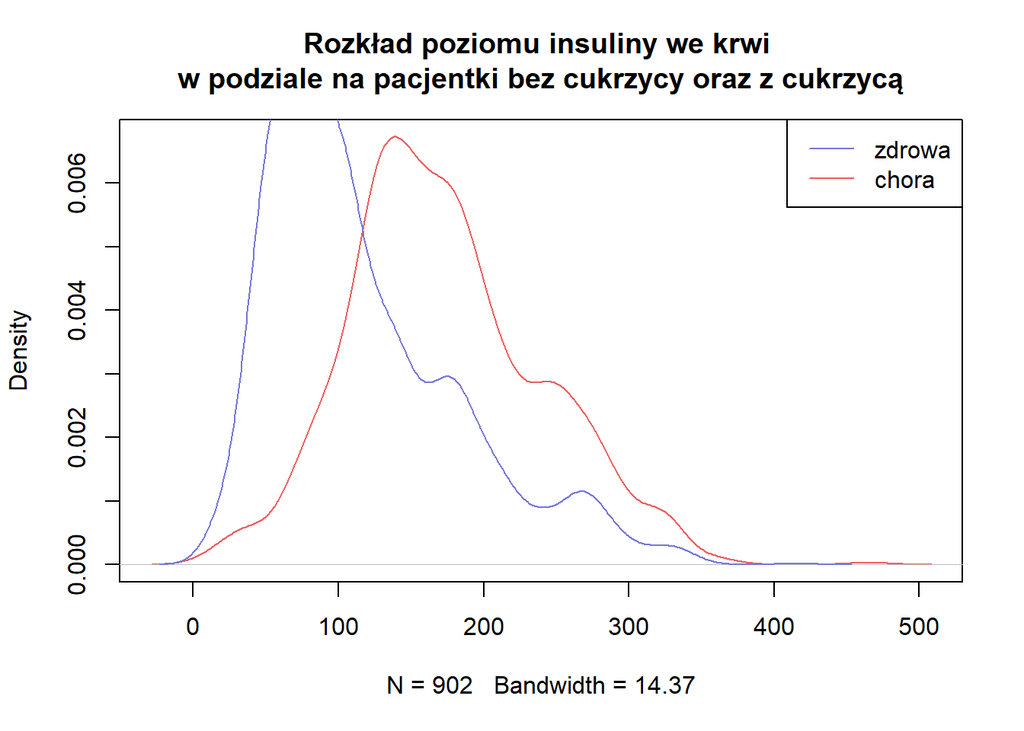

```r
plot(density(dane$Insulin[dane$Outcome==1]), col="#ee5e5e", main="Rozkład poziomu insuliny we krwi \nw podziale na pacjentki bez cukrzycy oraz z cukrzycą")
lines(density(dane$Insulin[dane$Outcome==0]), col="#7777D9")
legend("topright", legend=c("zdrowa", "chora"), col=c("#7777D9", "#ee5e5e"), lty=1)
```

```r
dane |>
  group_by(Outcome) |>
  summarise(Min=min(Insulin),
            Q1=quantile(Insulin, 0.25),
            Mean=mean(Insulin),
            Q3=quantile(Insulin, 0.75),
            Max=max(Insulin),
            sd=sd(Insulin),
            V=sd(Insulin)/mean(Insulin)*100,
            n=n()) |>
  kable() |>
  kable_styling(bootstrap_options = "striped")
```

| Outcome | Min | Q1 | Mean | Q3 | Max | sd | V | n |
| --- | --- | --- | --- | --- | --- | --- | --- | --- |
| 0 | 15 | 67 | 116.9358 | 152.0000 | 415 | 66.57452 | 56.93256 | 1779 |
| 1 | 14 | 130 | 173.3617 | 213.4432 | 465 | 65.71266 | 37.90496 | 902 |

Poniżej wyświetlono wyniki testu Shapiro-Wilka dla obu grup pacjentów dla zmiennej `Insulin`. W obu grupach p-value z testu jest bardzo bliskie zeru. Jednoznacznie należy odrzucić hipotezę o normalności rozkładu poziomu insuliny we krwi w grupach.

```r
dane |>
  group_by(Outcome) |>
  shapiro_test(Insulin) |>
  kable() |>
  kable_styling()
```

| Outcome | variable | statistic | p |
| --- | --- | --- | --- |
| 0 | Insulin | 0.9099224 | 0 |
| 1 | Insulin | 0.9832842 | 0 |

```r
var.test(dane[dane$Outcome==0, 'Insulin'], dane[dane$Outcome==1, 'Insulin'])
```

```
    F test to compare two variances

data:  dane[dane$Outcome == 0, "Insulin"] and dane[dane$Outcome == 1, "Insulin"]
F = 1.0264, num df = 1778, denom df = 901, p-value = 0.6573
alternative hypothesis: true ratio of variances is not equal to 1
95 percent confidence interval:
 0.9153816 1.1484372
sample estimates:
ratio of variances
          1.026403
```

Wariancje w obu grupach są takie same i nie pojawia się rozkład normalny. Testem odpowiednim do sprawdzenia równości średniej wieku w grupach przy takich założeniach byłby test Manna-Whitneya. Z powodu dużej liczebności próby zdecydowano się użyć jednak testu $T$, mimo braku normalności.

```r
t.test(dane[dane$Outcome==0, 'Insulin'], dane[dane$Outcome==1, 'Insulin'], var.equal = F, alternative = "less")
```

```
    Welch Two Sample t-test

data:  dane[dane$Outcome == 0, "Insulin"] and dane[dane$Outcome == 1, "Insulin"]
t = -20.915, df = 1831.4, p-value < 2.2e-16
alternative hypothesis: true difference in means is less than 0
95 percent confidence interval:
      -Inf -51.98599
sample estimates:
mean of x mean of y
 116.9358  173.3617
```

Test $T$ każe nam odrzucić hipotezę o równości średniego poziomu insuliny we krwi w grupach pacjentek chorych na cukrzycę oraz zdrowych (p-value bliskie zeru).